# Hierarchal Clustering

```r
# creates some nice colours for use in plotting.
source('Example/Visualisation/my_functions.R')
```

# Libraries

```r
library(reshape2)
library(ggdendro)
library(ggplot2)
library(cowplot)
library(dplyr)
library(RColorBrewer)
library(scico)
library(ggpubr)
```

# Load distance matrices

Distance matrices

```r
# entire population
jaccard = read.csv('Example/Outputs/DistanceMatrixJaccard.csv')
```

Convert to long data format for use in heatmaps

```r
jaccard_long = melt(jaccard)
```

## Dendrogram grobs

```r
category_legend = guides(colour = guide_legend(override.aes = list(size=5), nrow = 3))

y_scale = scale_y_continuous(
    name="Jaccard distance",
    breaks = c(0, 0.2, 0.4, 0.6, 0.8, 1.0),
    limits=c(-0.5, 1))

remove_axis_arrange_legend = theme(axis.title.x=element_blank(),
        axis.text.x=element_blank(),
        axis.ticks.x=element_blank(),
        axis.line = element_blank(),
        axis.title.y=element_blank(),
        axis.text.y=element_blank(),
        axis.ticks.y=element_blank(),
        legend.position = "bottom",
        legend.box = "vertical",
        legend.justification = ("right")
  )

size_scaling =  scale_size_continuous(
    breaks = c(20, 40, 60, 80, 100),
    labels = c(20, 40, 60, 80, 100),
    limits = c(0, 100),
    range = c(2,6)
   )

shifted_y_scale = scale_y_continuous(
    name="Jaccard distance",
    breaks = c(0, 0.2, 0.4, 0.6, 0.8, 1.0),
    limits=c(-0.5, 1))
```

Heatmap grobs

```r
heatmap_theme = theme(axis.text.y = element_blank(),
        axis.title.y = element_blank(),
        axis.ticks.y = element_blank(),
        legend.position = 'top',
        axis.text.x = element_text(
          angle = 90,
          hjust = 1,
          vjust = 0.5,
          size = 12))


z_axis_scale = scico::scale_fill_scico(
    palette = "roma",
    limits = c(0, 1))
```

# Data cleaning

We wrangle the raw distance matrices into a form that can be used as an input to as.dist. Really ought to convert this into a function…

```r
symptom_names = jaccard[,1]
jaccard = jaccard[,-1]
rownames(jaccard) = symptom_names
jaccard_dist = as.dist(jaccard)
```

# Extract symptom_names from datasets

We join the the lookup table that provides fromatted names for symptoms and assigns categories.

```r
# entire population
symptom_names_df = data.frame(symptom_names)
colnames(symptom_names_df) <- 'Symptom'
```

Perform joins and do formatting

```r
symptom_proportions = read.csv('Example/Outputs/symptom_proportions.csv')
colnames(symptom_proportions) = c('Symptom', 'Proportion')
```

```r
symptom_names_df = symptom_names_df %>%
  inner_join(categories) %>%
  inner_join(symptom_proportions) %>%
  mutate(
    cases_with_symptom_prop = round(Proportion*100)) %>%
  mutate(symptom_name_formatted_with_perc = paste(
    Symptom,
    " (",
    cases_with_symptom_prop,
    "%)",
    sep = ""
  ))
```

```r
symptom_names_df
```

| Symptom | Category | Proportion | cases_with_symptom_prop | symptom_name_formatted_with_perc |
| --- | --- | --- | --- | --- |
| A | Category 1 | 0.2833333 | 28 | A (28%) |
| B | Category 1 | 0.2800000 | 28 | B (28%) |
| C | Category 1 | 0.3844444 | 38 | C (38%) |
| D | Category 2 | 0.4722222 | 47 | D (47%) |
| E | Category 2 | 0.4555556 | 46 | E (46%) |
| F | Category 2 | 0.3711111 | 37 | F (37%) |
| G | Category 3 | 0.2855556 | 29 | G (29%) |
| H | Category 3 | 0.4044444 | 40 | H (40%) |
| I | Category 3 | 0.4044444 | 40 | I (40%) |
| J | Category 3 | 0.3311111 | 33 | J (33%) |

# DendroHeatmaps

```r
text_size = 0.01
```

## CTAS Pillar 2

The code here is a bit tricky. To begin, we create a dendrogram using the h_clust function. We then extract the dendrogram as line segments using a combination of as.dendrogram and dendro_data. We do this since it allows much more low level graphical tweaking, and plotting other points on top.

```r
jaccard_dendro_dd_row = as.dendrogram(
  hclust(
    jaccard_dist,
    method = 'complete'
    )
  )
jaccard_dendro_data = dendro_data(jaccard_dendro_dd_row)
```

The dendro_data table contains the names that were on the Jaccard distance matrix. We join to the symptom information table so that we can encode more information onto the dendrogram.

```r
jaccard_dendro_data$labels = jaccard_dendro_data$labels %>%
  left_join(
    symptom_names_df,
    by = c('label' = 'Symptom')
    )
```

We now recreate the dendrogram in ggplot2, but we can make use of the additional data that has been added to the dendro_data table.

```r
remove_axis_arrange_legend = theme(
  axis.title.x=element_blank(),
        axis.line = element_blank(),
        axis.title.y=element_blank(),
        axis.text.y=element_blank(),
        axis.ticks.y=element_blank(),
        legend.position = "bottom",
        legend.box = "vertical",
        legend.justification = ("right"))
```

```r
dendrogram <- ggplot(segment(jaccard_dendro_data)) +
  geom_segment(
    aes(x=x, y=y, xend=xend, yend=yend)) +
  geom_text(
    data=label(jaccard_dendro_data),
    aes(
      label=symptom_name_formatted_with_perc,
      x=x,
      y=-0.05,
      angle='0',
      hjust = 1,
      label_size = text_size)) +
  geom_point(
    data = jaccard_dendro_data$labels,
    aes(
      x=x,
      y=0,
      size=cases_with_symptom_prop,
      color=Category)) +
  labs(
    title = 'Synthetic dataset',
    subtitle = 'Complete linkage',
    size = 'Cases with symptom (%)',
    color = 'Category') +
  theme_cowplot(font_size = 12) +
  remove_axis_arrange_legend +
  shifted_y_scale +
  colour_scale_all +
  size_scaling +
  coord_flip() +
  category_legend
```

```
Ignoring unknown aesthetics: label_size
```

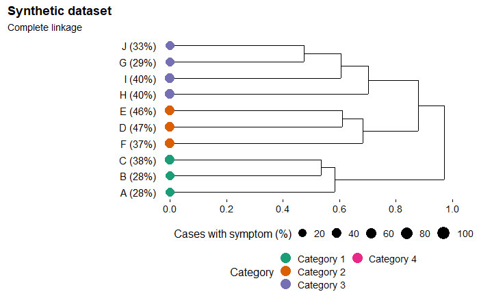

```r
dendrogram
```

### Heatmap

```r
# get the ordering from the dendrogram
jaccard_order = order.dendrogram(jaccard_dendro_dd_row)

# Order the levels according to their position in the dendrogram
jaccard_long$X = factor(
  x = jaccard_long$X,
  levels = jaccard_long$X[jaccard_order],
  ordered = TRUE
)

jaccard_long$variable = factor(
  x = jaccard_long$variable,
  levels = jaccard_long$X[rev(jaccard_order)],
  ordered = TRUE
)
```

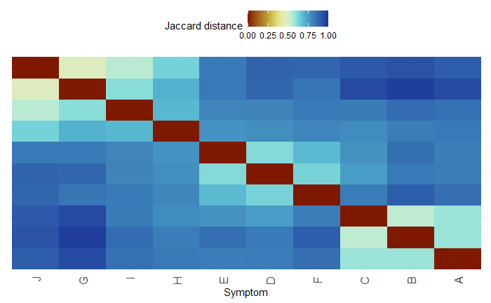

```r
heatmap <- ggplot(
  data = jaccard_long,
  aes(
    x = variable,
    y = X
    )
  ) +
  geom_tile(aes(fill = value)) +
  theme_minimal() +
  z_axis_scale +
  heatmap_theme +
  xlab("Symptom") +
  labs(fill = "Jaccard distance")

heatmap
```

### Arranging

```r
# you will have to manually align the symptoms with the heatmap
DendroHeatmap = ggdraw() +
  draw_plot(heatmap, x = 0, y = 0.15, width = .45, height = 0.86) +
  draw_plot(dendrogram, x = 0.35, y = 0, width = 0.56, height = 0.98)

ggsave(
  'Example/Figures/DendroHeatmap.png',
  plot = DendroHeatmap, width = 12)
```